# Question

Los envases compuestos son elaborados con Aluminio, Cartón y Polietileno, distribuidos en 6 capas, lo cual evita el contacto del alimento con el medio externo. La gráfica muestra la distribución porcentual aproximada de los materiales de un envases compuestos:

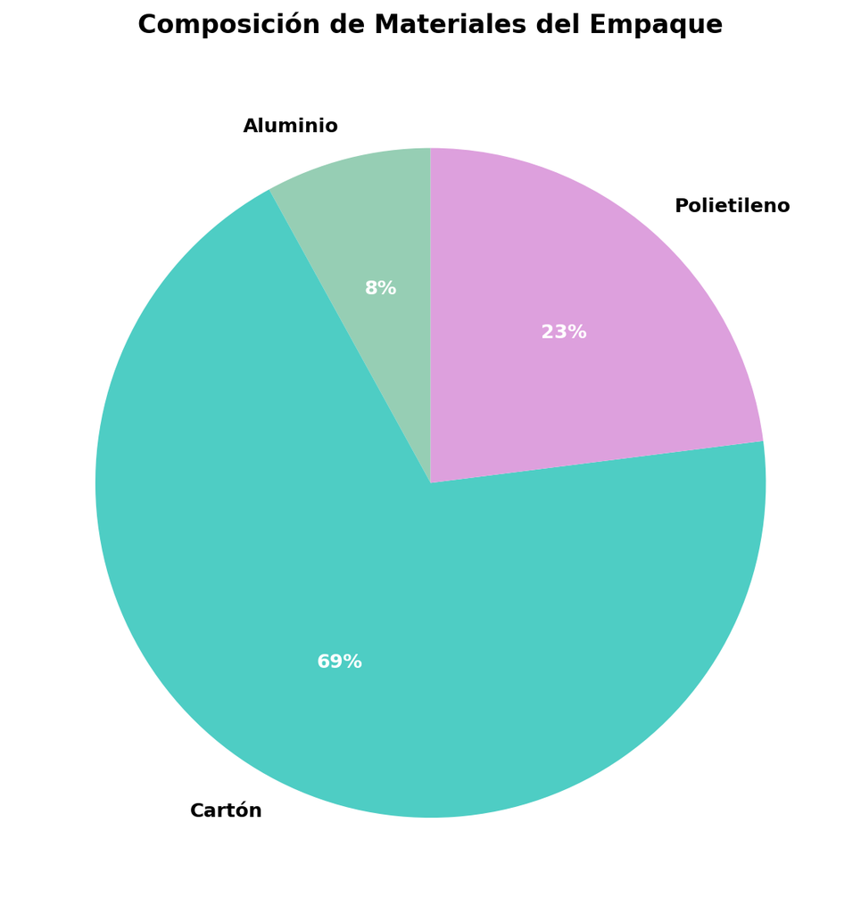

Las 6 capas del empaque se distribuyen así:

**Primera capa.** Cartón: protege los alimentos de la humedad atmosférica externa.

**Segunda capa.** Aluminio: brinda resistencia, forma y estabilidad.

**Tercera capa.** Cartón: ofrece adherencia fijando las capas de papel y aluminio.

**Cuarta capa.** Polietileno: evita la entrada de oxígeno y luz, y la pérdida de aromas.

**Quinta capa.** Cartón: evita que el alimento esté en contacto con el Polietileno.

**Sexta capa.** Cartón: garantiza por completo la protección del alimento.

Una persona afirma que los porcentajes de los materiales en el empaque son válidos para un empaque de 2 litros, pero que si se construye con la misma técnica un empaque de dos tercios, reduciendo las dimensiones a dos tercios, entonces los porcentajes también se reducen a dos tercios.

**Esta afirmación es falsa porque:**

## Answerlist

- Los porcentajes se conservarían porque la composición química de los materiales es la misma
- Los porcentajes se conservarían porque la masa total del empaque se mantiene constante
- Los porcentajes se conservarían sin importar el tamaño del empaque
- Los porcentajes se duplicarían al haber menos espacio vacío dentro del empaque

# Solution

Para resolver este problema de **argumentación matemática**, debemos analizar la afirmación falsa y determinar por qué es incorrecta según los principios de escalamiento y proporcionalidad.

**Análisis de la afirmación falsa:**

La persona afirma que al reducir las dimensiones del empaque a dos tercios, los porcentajes de materiales también se reducen a dos tercios. Esta afirmación es **matemáticamente incorrecta**.

**¿Por qué es falsa la afirmación?**

**Principio fundamental:** Los porcentajes representan proporciones relativas, no cantidades absolutas.

**Escalamiento de dimensiones:** - Factor de reducción lineal: 0,6666667 - Factor de reducción volumétrica: 0,6666667 ³ = 0,2963

**Composición del empaque original:** - Aluminio : 8 % - Cartón : 69 % - Polietileno : 23 %

**Composición del empaque reducido:** Los porcentajes se mantienen **exactamente iguales** porque:

1. **Proporcionalidad:** Todos los materiales se reducen en la misma proporción
2. **Conservación de ratios:** La relación entre materiales no cambia
3. **Escalamiento uniforme:** Las 6 capas mantienen sus proporciones relativas

**Demostración matemática:**

Si el empaque original tiene volumen V y el reducido tiene volumen 0,2963V:

- Aluminio original: 8% de V
- Aluminio reducido: 8% de 0,2963V = 2,37% de V

Pero como porcentaje del nuevo volumen total: 2,37% de V ÷ 0,2963V = **8%**

**Conclusión:**

La afirmación correcta es: **“Los porcentajes se conservarían sin importar el tamaño del empaque”**

Los porcentajes son **invariantes bajo escalamiento uniforme** porque representan proporciones relativas, no cantidades absolutas.

**¿Por qué las otras afirmaciones son incorrectas?**

- Confunden escalamiento lineal con cambios en composición
- No comprenden que los porcentajes son ratios, no cantidades
- Aplican incorrectamente conceptos de densidad o superficie
- No reconocen la invariancia de proporciones bajo escalamiento uniforme

## Answerlist

- Falso
- Falso
- Verdadero
- Falso

# Meta-information

exname: empaques_tetra_pak_argumentacion_escalamiento extype: schoice exsolution: 0010 exshuffle: TRUE exsection: Argumentación en Estadística y Proporcionalidad